# NFL_Analysis

## Introduction

We’re going to do some basic analysis on NFL teams from 2002-2020. This consists of the 16-game-per-season era.

Let’s import some important libraries.

```r
library(tidyverse)
```

```r
library(ggplot2)
```

For me, the dataset is already in the directory. You can also download it straight off the link

```r
df <- read_csv('standings.csv')
# data <- read_csv('http://www.habitatring.com/standings.csv') # if you want the data from online
```

First, we will conduct some exploration and try to understand the dataset first. Then, we will explore the relationship of points. We’ll explore points scored, points allowed, and point differential versus wins. Obviously, for individual games, measurements like point differential are highly correlated with wins, but over the average course of a season we might see different results.

Note: After the analysis, it makes more sense to plot pct instead (I think it takes into account draws as well). Overall the graphs should still look the same.

Finally, I would like to conduct a search for outliers of these statistics. For example, which team is the most ‘clutch’, that is, has the highest win rate with a low point differential. We could see the clutchest team in a season or the clutchest overall NFL team throughout the 16-game era. Alternatively, we could also explore the least clutch team, the “chokers”.

## Data analysis

Let’s first get a look of what’s in our data!

```r
head(df)
```

```
## # A tibble: 6 x 16
##   season conf  division  team   wins losses  ties   pct div_rank scored allowed
##    <dbl> <chr> <chr>     <chr> <dbl>  <dbl> <dbl> <dbl>    <dbl>  <dbl>   <dbl>
## 1   2002 AFC   AFC East  BUF       8      8     0 0.5          4    379     397
## 2   2002 AFC   AFC East  MIA       9      7     0 0.562        3    378     301
## 3   2002 AFC   AFC East  NE        9      7     0 0.562        2    381     346
## 4   2002 AFC   AFC East  NYJ       9      7     0 0.562        1    359     336
## 5   2002 AFC   AFC North BAL       7      9     0 0.438        3    316     354
## 6   2002 AFC   AFC North CIN       2     14     0 0.125        4    279     456
## # … with 5 more variables: net <dbl>, sov <dbl>, sos <dbl>, seed <dbl>,
## #   playoff <chr>
```

```r
names(df)
```

```
##  [1] "season"   "conf"     "division" "team"     "wins"     "losses"
##  [7] "ties"     "pct"      "div_rank" "scored"   "allowed"  "net"
## [13] "sov"      "sos"      "seed"     "playoff"
```

```r
summary(df)
```

```
##      season         conf             division             team
##  Min.   :2002   Length:608         Length:608         Length:608
##  1st Qu.:2006   Class :character   Class :character   Class :character
##  Median :2011   Mode  :character   Mode  :character   Mode  :character
##  Mean   :2011
##  3rd Qu.:2016
##  Max.   :2020
##
##       wins            losses            ties              pct
##  Min.   : 0.000   Min.   : 0.000   Min.   :0.00000   Min.   :0.0000
##  1st Qu.: 5.000   1st Qu.: 5.000   1st Qu.:0.00000   1st Qu.:0.3750
##  Median : 8.000   Median : 8.000   Median :0.00000   Median :0.5000
##  Mean   : 7.666   Mean   : 7.666   Mean   :0.03618   Mean   :0.5002
##  3rd Qu.:10.000   3rd Qu.:10.000   3rd Qu.:0.00000   3rd Qu.:0.6250
##  Max.   :16.000   Max.   :16.000   Max.   :1.00000   Max.   :1.0000
##
##     div_rank        scored         allowed           net
##  Min.   :1.00   Min.   : 47.0   Min.   : 56.0   Min.   :-261.00
##  1st Qu.:1.75   1st Qu.:290.0   1st Qu.:306.8   1st Qu.: -70.25
##  Median :2.50   Median :348.0   Median :346.0   Median :   1.00
##  Mean   :2.50   Mean   :339.6   Mean   :339.6   Mean   :   0.00
##  3rd Qu.:3.25   3rd Qu.:396.0   3rd Qu.:389.2   3rd Qu.:  70.00
##  Max.   :4.00   Max.   :606.0   Max.   :517.0   Max.   : 315.00
##
##       sov              sos                seed        playoff
##  Min.   :0.0000   Min.   :0.003906   Min.   :1.00   Length:608
##  1st Qu.:0.3750   1st Qu.:0.472656   1st Qu.:2.00   Class :character
##  Median :0.4192   Median :0.496094   Median :4.00   Mode  :character
##  Mean   :0.4001   Mean   :0.474282   Mean   :3.53
##  3rd Qu.:0.4531   3rd Qu.:0.519531   3rd Qu.:5.00
##  Max.   :0.6042   Max.   :0.589844   Max.   :7.00
##                                      NA's   :378
```

There are honestly a lot of columns. For now, let’s filter our data. What columns should we keep? season, team, wins, losses, ties, pct, scored, allowed, and net all make sense. Let’s also keep seed, it might come in handy later.

```r
df <- select(df, c(season, team, wins, losses, ties, pct, scored, allowed, net, seed))
head(df)
```

```
## # A tibble: 6 x 10
##   season team   wins losses  ties   pct scored allowed   net  seed
##    <dbl> <chr> <dbl>  <dbl> <dbl> <dbl>  <dbl>   <dbl> <dbl> <dbl>
## 1   2002 BUF       8      8     0 0.5      379     397   -18    NA
## 2   2002 MIA       9      7     0 0.562    378     301    77    NA
## 3   2002 NE        9      7     0 0.562    381     346    35    NA
## 4   2002 NYJ       9      7     0 0.562    359     336    23     4
## 5   2002 BAL       7      9     0 0.438    316     354   -38    NA
## 6   2002 CIN       2     14     0 0.125    279     456  -177    NA
```

There are 32 teams in the NFL, and 19 years in this dataset. Let’s create an aggregated dataset where we combine all of a teams stats.

```r
combined_df <- df %>%
  group_by(team) %>%
  summarise(wins = sum(wins), losses = sum(losses), ties = sum(ties),
            pct = mean(pct), scored = sum(scored), allowed = sum(allowed),
            net = sum(net), seed = mean(seed))
print(combined_df)
```

```
## # A tibble: 35 x 9
##    team   wins losses  ties   pct scored allowed   net  seed
##    <chr> <dbl>  <dbl> <dbl> <dbl>  <dbl>   <dbl> <dbl> <dbl>
##  1 ARI     129    161     2 0.447   6036    6880  -844    NA
##  2 ATL     153    138     1 0.505   6799    6629   170    NA
##  3 BAL     171    121     0 0.592   6684    5497  1187    NA
##  4 BUF     130    162     0 0.467   5901    6462  -561    NA
##  5 CAR     151    140     1 0.518   6306    6299     7    NA
##  6 CHI     143    150     0 0.499   6028    6207  -179    NA
##  7 CIN     135    153     4 0.465   6300    6544  -244    NA
##  8 CLE      92    199     1 0.334   5223    6751 -1528    NA
##  9 DAL     160    132     0 0.536   6715    6347   368    NA
## 10 DEN     164    128     0 0.549   6776    6334   442    NA
## # … with 25 more rows
```

Note: I chose to sum up all the data, except in pct and seed, where I thought it would make more sense to have them be averages.

Alright, now it’s time to do some very basic plotting. Let’s just look at scored vs pct in the original data.

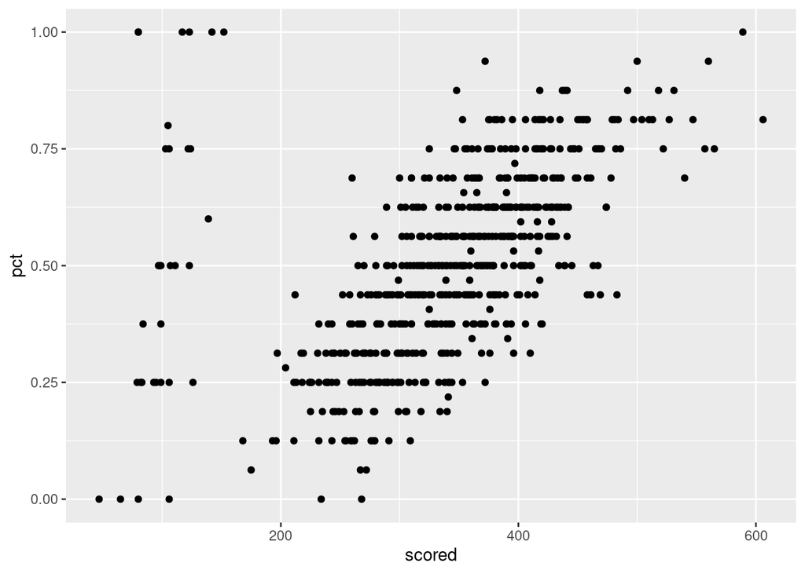

```r
ggplot(data=df, aes(x = scored, y = pct)) + geom_point()
```

Very interesting. For the most part, of course we see a direct positive correlation. The more you score, the more you win, right? But what about the line on the left, which essentially has a bunch of super low scoring team. My hypothesis is that some of our data is missing, so let’s go ahead and split by year.

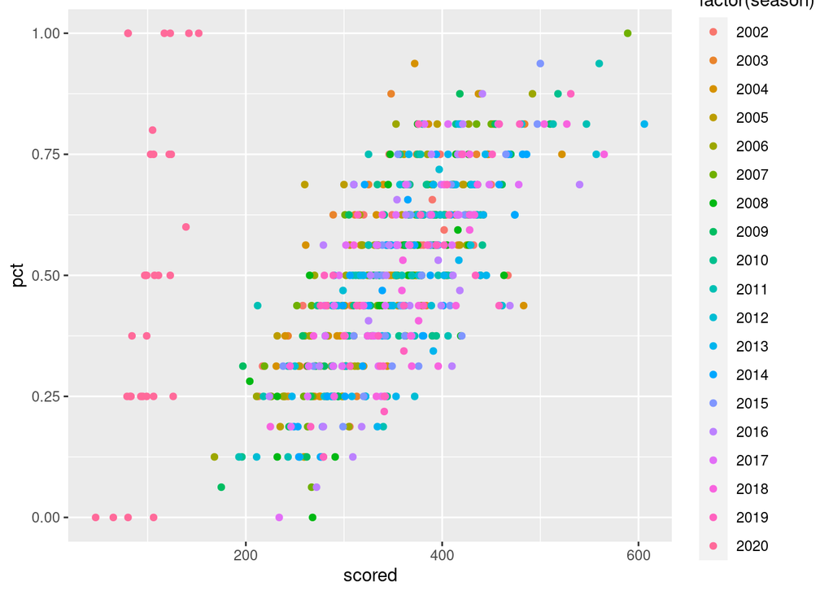

```r
ggplot(data=df, aes(x = scored, y = pct, color=factor(season))) + geom_point()
```

Okay, the colors are confusing, but I think we can clearly tell that there’s something wrong with the data from 2020 or so. Let’s plot the filtered data from 2016 onwards.

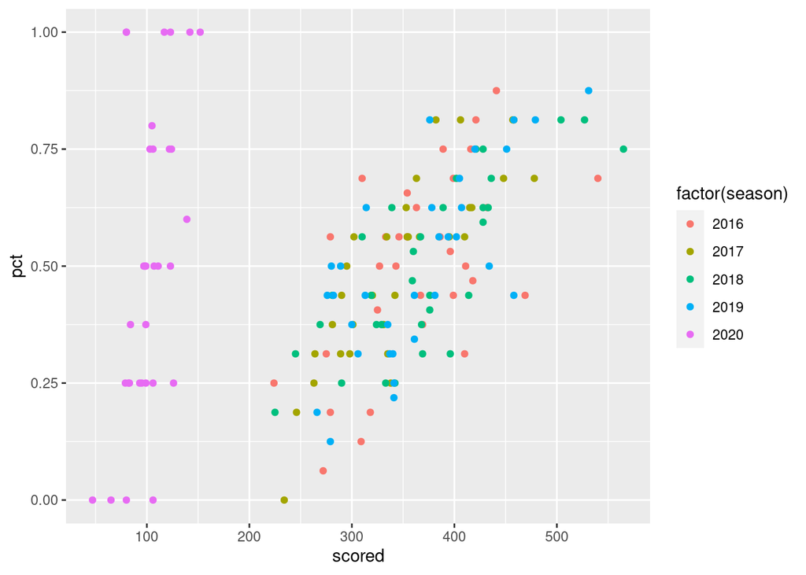

```r
df_2016_plus <- subset(df, df$season >= 2016)
ggplot(data=df_2016_plus, aes(x = scored, y = pct, color=factor(season))) + geom_point()
```

Now it’s very clear that we only have problems with 2020. Let’s inspect the data.

```r
df_2020 <- subset(df, df$season == 2020)
head(df_2020)
```

```
## # A tibble: 6 x 10
##   season team   wins losses  ties   pct scored allowed   net  seed
##    <dbl> <chr> <dbl>  <dbl> <dbl> <dbl>  <dbl>   <dbl> <dbl> <dbl>
## 1   2020 BUF       4      0     0 1        123     100    23     2
## 2   2020 MIA       1      3     0 0.25      93      96    -3    NA
## 3   2020 NE        2      2     0 0.5       97      92     5    NA
## 4   2020 NYJ       0      4     0 0         65     131   -66    NA
## 5   2020 BAL       3      1     0 0.75     122      73    49     6
## 6   2020 CIN       1      2     1 0.375     99      99     0    NA
```

```r
summary(df_2020)
```

```
##      season         team                wins           losses
##  Min.   :2020   Length:32          Min.   :0.000   Min.   :0.000
##  1st Qu.:2020   Class :character   1st Qu.:1.000   1st Qu.:1.000
##  Median :2020   Mode  :character   Median :2.000   Median :2.000
##  Mean   :2020                      Mean   :1.969   Mean   :1.969
##  3rd Qu.:2020                      3rd Qu.:3.000   3rd Qu.:3.000
##  Max.   :2020                      Max.   :4.000   Max.   :4.000
##
##       ties             pct             scored          allowed
##  Min.   :0.0000   Min.   :0.0000   Min.   : 47.00   Min.   : 56.0
##  1st Qu.:0.0000   1st Qu.:0.2500   1st Qu.: 83.75   1st Qu.: 92.0
##  Median :0.0000   Median :0.5000   Median :101.00   Median :100.5
##  Mean   :0.0625   Mean   :0.5047   Mean   :102.25   Mean   :102.2
##  3rd Qu.:0.0000   3rd Qu.:0.7500   3rd Qu.:118.25   3rd Qu.:120.8
##  Max.   :1.0000   Max.   :1.0000   Max.   :152.00   Max.   :146.0
##
##       net              seed
##  Min.   :-66.00   Min.   :1.00
##  1st Qu.:-20.50   1st Qu.:2.25
##  Median : -1.00   Median :4.00
##  Mean   :  0.00   Mean   :4.00
##  3rd Qu.: 23.75   3rd Qu.:5.75
##  Max.   : 51.00   Max.   :7.00
##                   NA's   :18
```

It’s clear that our data is a bit outdated and doesn’t have everything in the 2020 season. Let’s update our dataset to only include analysis from 2002-2019 for the graphs. Let’s update the combined dataset as well. (as means may be lopsided by overweighting 2020).

```r
df <- subset(df, df$season < 2020)
combined_df <- df %>%
  group_by(team) %>%
  summarise(wins = sum(wins), losses = sum(losses), ties = sum(ties),
            pct = mean(pct), scored = sum(scored), allowed = sum(allowed),
            net = sum(net), seed = mean(seed))
head(df) #to check
```

```
## # A tibble: 6 x 10
##   season team   wins losses  ties   pct scored allowed   net  seed
##    <dbl> <chr> <dbl>  <dbl> <dbl> <dbl>  <dbl>   <dbl> <dbl> <dbl>
## 1   2002 BUF       8      8     0 0.5      379     397   -18    NA
## 2   2002 MIA       9      7     0 0.562    378     301    77    NA
## 3   2002 NE        9      7     0 0.562    381     346    35    NA
## 4   2002 NYJ       9      7     0 0.562    359     336    23     4
## 5   2002 BAL       7      9     0 0.438    316     354   -38    NA
## 6   2002 CIN       2     14     0 0.125    279     456  -177    NA
```

```r
head(combined_df) # to check
```

```
## # A tibble: 6 x 9
##   team   wins losses  ties   pct scored allowed   net  seed
##   <chr> <dbl>  <dbl> <dbl> <dbl>  <dbl>   <dbl> <dbl> <dbl>
## 1 ARI     127    159     2 0.444   5938    6788  -850    NA
## 2 ATL     153    134     1 0.533   6693    6491   202    NA
## 3 BAL     168    120     0 0.583   6562    5424  1138    NA
## 4 BUF     126    162     0 0.438   5778    6362  -584    NA
## 5 CAR     149    138     1 0.519   6207    6197    10    NA
## 6 CHI     139    149     0 0.483   5923    6107  -184    NA
```

Now let’s go ahead and plot scored, allowed, and net vs pct for our data.

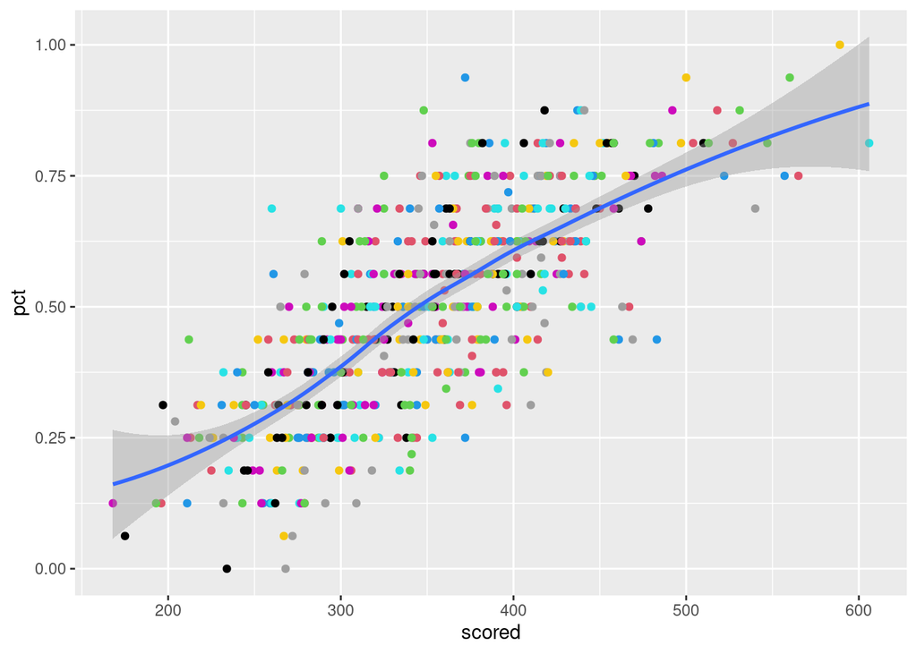

```r
ggplot(data=df, aes(x=scored, y=pct)) + geom_point(color=factor(df$season)) + geom_smooth()
```

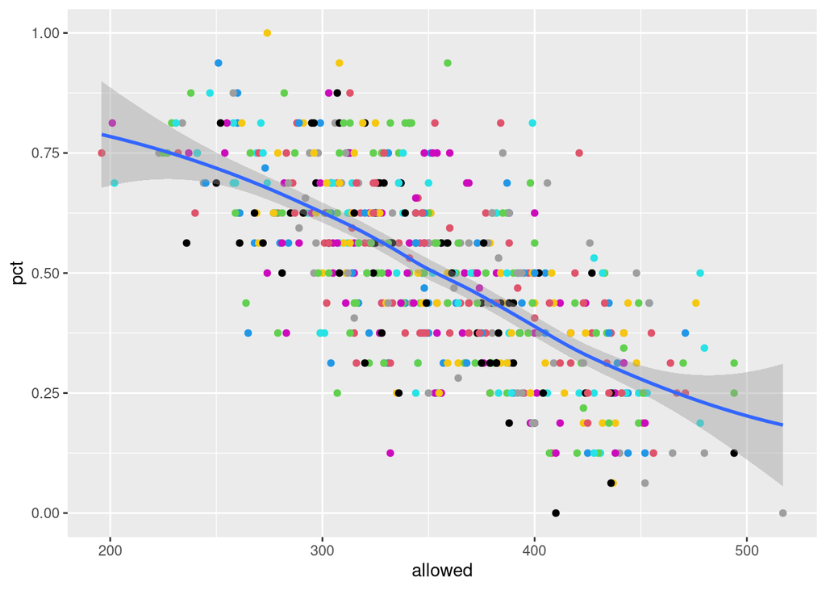

```r
ggplot(data=df, aes(x=allowed, y=pct)) + geom_point(color=factor(df$season)) + geom_smooth()
```

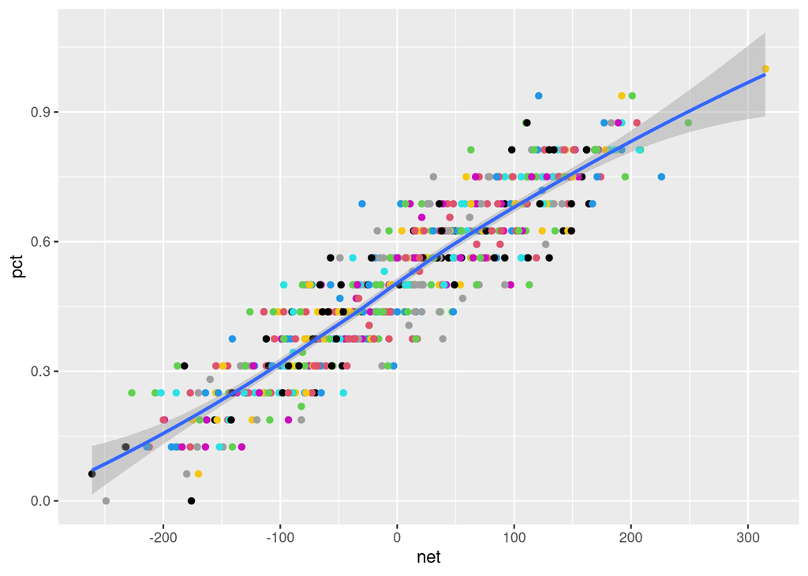

```r
ggplot(data=df, aes(x=net, y=pct)) + geom_point(color=factor(df$season)) + geom_smooth()
```

Honestly, just as expected. There is a strong correlation between scored points, allowed points, and an extremely strong correlation for net points. Let’s calculate the correlation exactly.

```r
print(cor(x=df$scored, y=df$pct))
```

```
## [1] 0.7430125
```

```r
print(cor(x=df$allowed, y=df$pct))
```

```
## [1] -0.6783799
```

```r
print(cor(x=df$net, y=df$pct))
```

```
## [1] 0.915151
```

Interestingly enough, defense is not as correlated. There’s too many dots on these graphs, and labeling would be a visual nightmare. Let’s switch over to the combined datasets. Let’s look at the generic plots before answering/asking any questions.

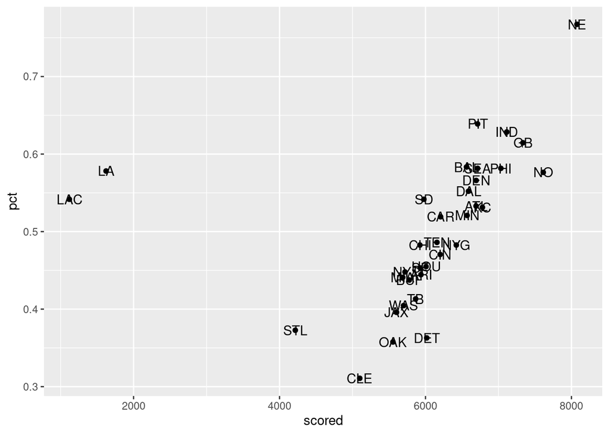

```r
ggplot(data=combined_df, aes(x=scored, y=pct)) + geom_point() + geom_text(aes(label=combined_df$team))
```

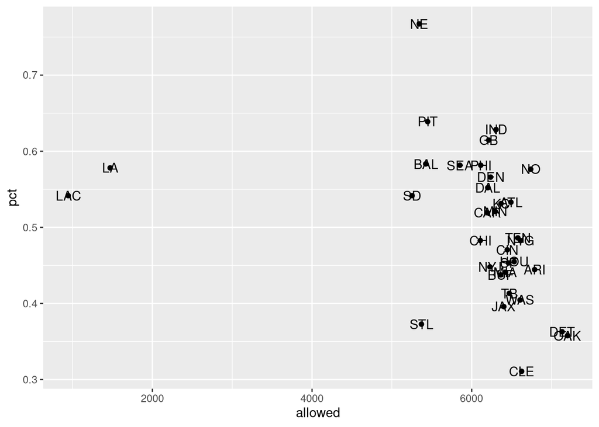

```r
ggplot(data=combined_df, aes(x=allowed, y=pct)) + geom_point() + geom_text(aes(label=combined_df$team))
```

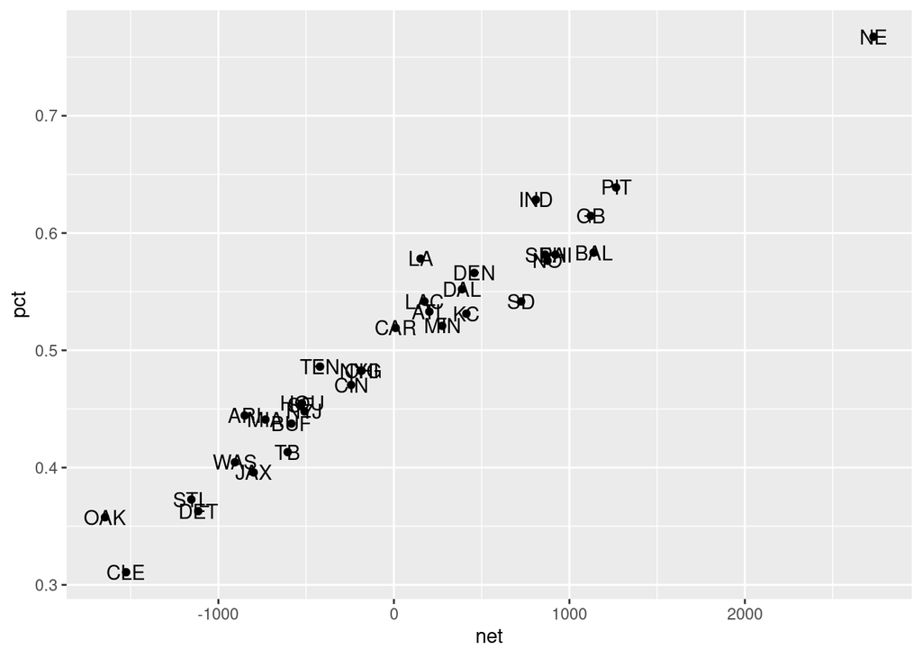

```r
ggplot(data=combined_df, aes(x=net, y=pct)) + geom_point() + geom_text(aes(label=combined_df$team))
```

The data doesn’t look that linear/correlated. It seems to be a problem with LAC and LA. Maybe they are new teams?